# Parcours Data Analyst

## Triple lissage expontentiel de Holt-Winters

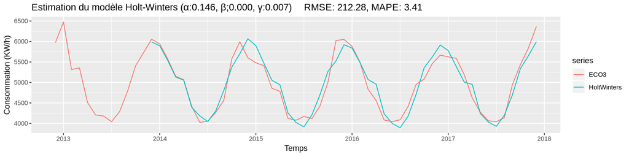

```r
HW <- forecast(HoltWinters(ECO3),12)
res <- c(as.numeric(HW$fitted),as.numeric(HW$mean))
res <- ts(res,frequency=12,start=c(2012,12),end=c(2017,12))
α <- HW$model$alpha
β <- HW$model$beta
γ <- HW$model$gamma
main <- sprintf("Estimation du modèle Holt-Winters (α:%.3f, β;%.3f, γ:%.3f)\tRMSE: %.2f, MAPE: %.2f"
                ,α,β,γ,accuracy(HW)[,"RMSE"],accuracy(HW)[,"MAPE"])
autoplot(cbind(ECO3,HoltWinters=res),xlab="Temps",ylab="Consommation (KW/h)", main=main)
```

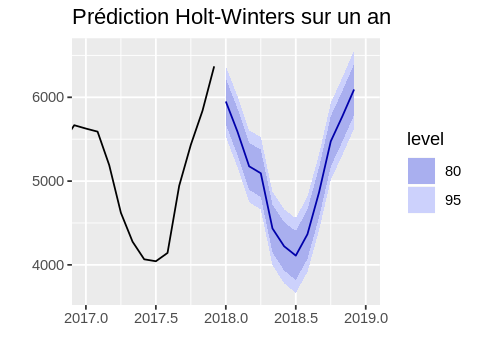

```r
options(repr.plot.width=4)
HW <- HoltWinters(ECO3,
                   # 𝑎𝑙𝑝ℎ𝑎 parameter of Holt-Winters Filter.
                   alpha = α,
                   # 𝑏𝑒𝑡𝑎 parameter of Holt-Winters Filter.
                   # If set to FALSE, the function will do exponential smoothing.
                   beta = β,
                   # 𝑔𝑎𝑚𝑚𝑎 parameter used for the seasonal component.
                   # If set to FALSE, an non-seasonal model is fitted.
                   gamma = γ,
                   #seasonal = "additive",
                   #start.periods = 12, l.start = NULL, b.start = NULL, s.start = NULL,
                   #optim.start = c(alpha = 0.3, beta = 0.1, gamma = 0.1),
                   #optim.control = list()
                  )
main <- "Prédiction Holt-Winters sur un an"
res <- forecast(HW,12)
res <- autoplot(res,xlab="",ylab="",main=main)
res$coordinates$limits$x <- c(2017,2019)
res
options(repr.plot.width=12)
```

- Paramètre α : lissage sur les valeurs
- Paramètre β : lissage sur la tendance
- Paramètre γ : lissage sur la saisonnalité

### Analyse a posteriori : test sur l'année 2017

```r
# Partage de la série en training/testing
train <- window(ECO3,end = c(2016,11))
test <- window(ECO3,start = c(2016,12))
HoltWinters_ECO3 <- forecast(HoltWinters(train, alpha=α, beta=β, gamma=γ),12)
```

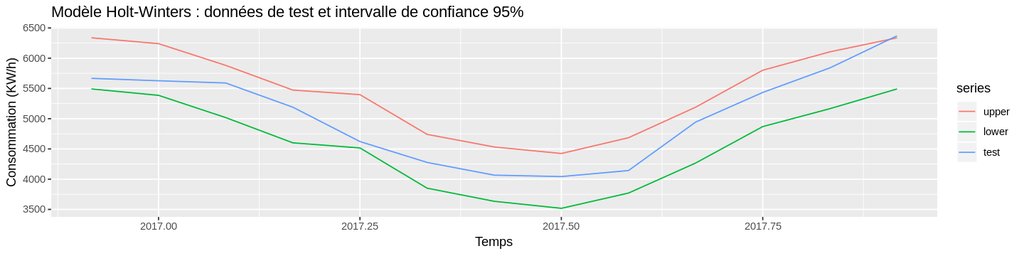

```r
res <- HoltWinters_ECO3
upper <- ts(res$upper[,2],frequency=12,start=c(2016,12),end=c(2017,12))
lower <- ts(res$lower[,2],frequency=12,start=c(2016,12),end=c(2017,12))
main="Modèle Holt-Winters : données de test et intervalle de confiance 95%"
autoplot(cbind(upper,lower,test),xlab="Temps",ylab="Consommation (KW/h)", main=main)
```

```r
accuracy(HoltWinters_ECO3, test, d=12, D=1)
```

|  | ME | RMSE | MAE | MPE | MAPE | MASE | ACF1 | Theil's U |
| --- | --- | --- | --- | --- | --- | --- | --- | --- |
| Training set | -36.8322222 | 215.8384 | 170.4281 | -0.84095399 | 3.453910 | 0.0011266866 | 0.23324278 | NA |
| Test set | -0.5005319 | 173.7028 | 147.7458 | -0.07745685 | 2.895073 | 0.0009767355 | 0.03450724 | 0.3893065 |

```r
shapiro.test(HoltWinters_ECO3$residuals)
print("H0:normality")
Box.test(HoltWinters_ECO3$residuals, lag=12, type="Ljung-Box")
print("H0:independence")
```

```
	Shapiro-Wilk normality test

data:  HoltWinters_ECO3$residuals
W = 0.9818, p-value = 0.8045
```

```
[1] "H0:normality"
```

```
	Box-Ljung test

data:  HoltWinters_ECO3$residuals
X-squared = 24.731, df = 12, p-value = 0.01615
```

```
[1] "H0:independence"
```

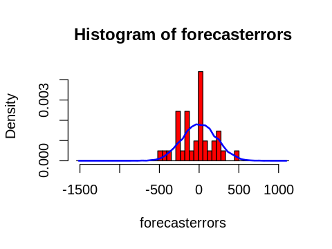

```r
options(repr.plot.width=4)
plotForecastErrors(HoltWinters_ECO3$residuals)
options(repr.plot.width=12)
```

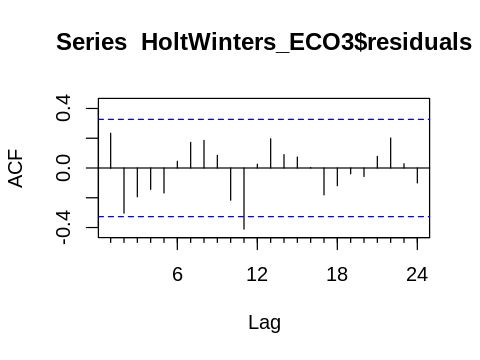

```r
options(repr.plot.width=4)
Acf(HoltWinters_ECO3$residuals)
options(repr.plot.width=12)
```

## Modèle SARIMA

```r
# Recommandations de la documentation pour trouver les paramètres optimaux
SARIMA <- auto.arima(ECO3, stepwise=FALSE, approximation=FALSE, parallel=TRUE)
#Des résultats de auto.arima
order=c(1,0,0)
seasonal=c(0,1,1)
```

**order** Spécification de la partie non saisonnière du modèle ARIMA: les trois composantes (p, d, q) sont l'ordre AR, le degré de différenciation et l'ordre MA

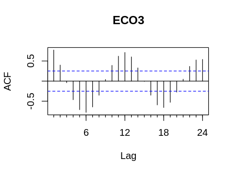

```r
options(repr.plot.width=4)
Acf(ECO3,main="ECO3")
options(repr.plot.width=12)
```

**seasonal** Spécification de la partie saisonnière du modèle ARIMA, plus la période (qui utilise par défaut la fréquence (y))

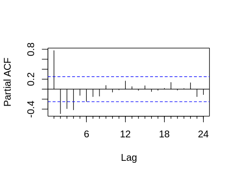

```r
options(repr.plot.width=4)
Pacf(ECO3,main="")
options(repr.plot.width=12)
```

auto.arima(ECO3, stepwise=FALSE, approximation=FALSE, parallel=TRUE)

```r
SARIMA
```

```
Series: ECO3
ARIMA(1,0,0)(0,1,1)[12]

Coefficients:
         ar1     sma1
      0.1831  -0.8533
s.e.  0.1507   0.7182

sigma^2 estimated as 53262:  log likelihood=-341.63
AIC=689.26   AICc=689.79   BIC=694.93
```

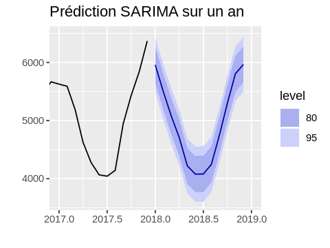

```r
options(repr.plot.width=4)
main <- "Prédiction SARIMA sur un an"
res <- forecast(SARIMA,12)
res <- autoplot(res,xlab="",ylab="",main=main)
res$coordinates$limits$x <- c(2017,2019)
res
options(repr.plot.width=12)
```

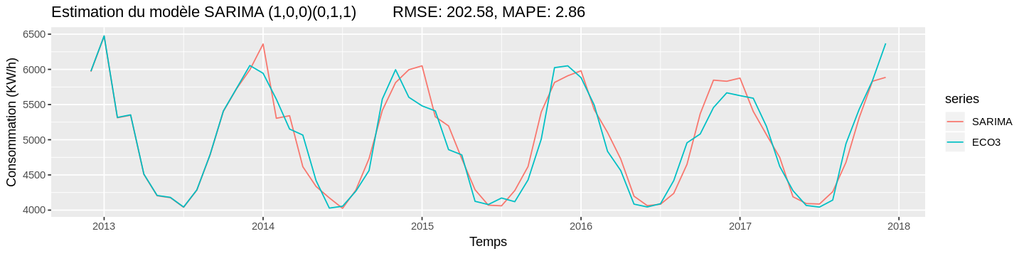

```r
res <- forecast(SARIMA,12)
res <- c(as.numeric(res$fitted),as.numeric(res$mean))
res <- ts(res,frequency=12,start=c(2012,12),end=c(2017,12))
main <- sprintf("Estimation du modèle SARIMA (1,0,0)(0,1,1)\tRMSE: %.2f, MAPE: %.2f",
                accuracy(SARIMA)[,"RMSE"],accuracy(SARIMA)[,"MAPE"])
autoplot(cbind(SARIMA=res,ECO3),xlab="Temps",ylab="Consommation (KW/h)", main=main)
```

### Analyse a posteriori : test sur l'année 2017

```r
# Partage de la série en training/testing
train <- window(ECO3,end = c(2016,11))
test <- window(ECO3,start = c(2016,12))
SARIMA <- forecast(Arima(train,order=order,seasonal=seasonal),12)
```

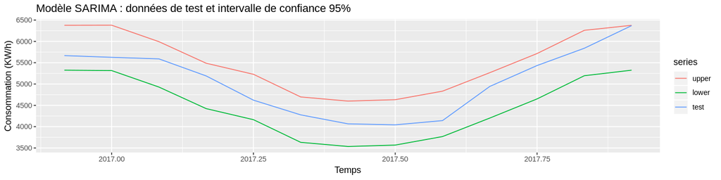

```r
res <- SARIMA
upper <- ts(res$upper[,2],frequency=12,start=c(2016,12),end=c(2017,12))
lower <- ts(res$lower[,2],frequency=12,start=c(2016,12),end=c(2017,12))
main="Modèle SARIMA : données de test et intervalle de confiance 95%"
autoplot(cbind(upper,lower,test),xlab="Temps",ylab="Consommation (KW/h)", main=main)
```

```r
accuracy(SARIMA, test)
```

|  | ME | RMSE | MAE | MPE | MAPE | MASE | ACF1 | Theil's U |
| --- | --- | --- | --- | --- | --- | --- | --- | --- |
| Training set | -42.12956 | 225.2118 | 155.5076 | -0.8884174 | 3.070562 | 0.6603799 | -0.01385231 | NA |
| Test set | 29.19575 | 163.3221 | 145.3841 | 0.5115211 | 2.856799 | 0.6173893 | 0.19379248 | 0.3886803 |

```r
shapiro.test(SARIMA$residuals)
print("H0:normality")
Box.test(SARIMA$residuals, fitdf=1+0, lag=12, type="Ljung-Box")
print("H0:independence")
```

```
	Shapiro-Wilk normality test

data:  SARIMA$residuals
W = 0.94725, p-value = 0.03109
```

```
[1] "H0:normality"
```

```
	Box-Ljung test

data:  SARIMA$residuals
X-squared = 14.294, df = 11, p-value = 0.2171
```

```
[1] "H0:independence"
```

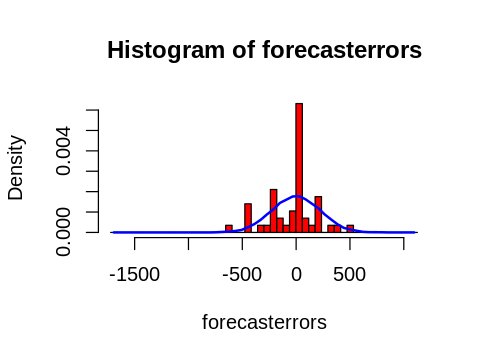

```r
options(repr.plot.width=4)
plotForecastErrors(SARIMA$residuals)
options(repr.plot.width=12)
```

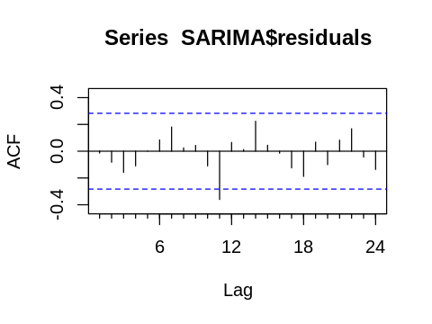

```r
options(repr.plot.width=4)
Acf(SARIMA$residuals)
options(repr.plot.width=12)
```

[figure not shown]